# PML project

NH Forensic

16/11/2020

## R Markdown

This report sets out my review of the personal activity data obtained from 6 participants that performed dumbell lifts while using movement sensors attached to their bodies.

The first step of my review is to load the relevant data and the necessary R package into my R work space:

```r
library(caret)
library(rattle)
Data <- read.csv("pml-training.csv")
testData <- read.csv("pml-testing.csv")
```

I then split the training data further between a training data set and a validation data set and review the high level features of the training data set:

```r
set.seed(1111)
trainDatatemp <- createDataPartition(y=Data$classe, p=0.7, list = FALSE)
trainData <- Data[trainDatatemp, ]
valData <- Data[-trainDatatemp, ]
dim(trainData)
```

```
## [1] 13737   160
```

The above shows that there are 160 variables in the data set. The following functionremoves variables that have very few unique values relative to the number of samples:

```r
nouniqueval <- nearZeroVar(trainData)
trainData1 <- trainData[, -nouniqueval]
valData1 <- valData[, -nouniqueval]
dim(trainData1)
```

```
## [1] 13737   108
```

```r
NAvariables <- sapply(trainData1, function(x) mean(is.na(x))) > 0.90
trainData2 <- trainData1[, NAvariables==F]
valData2 <- valData1[, NAvariables==F]
dim(trainData2)
```

```
## [1] 13737    59
```

The above shows that the number of variables decreased to 59. We then remove the first 7 variables given that these do not appear to influence the outcome:

```r
trainData3 <- trainData2[, -(1:7)]
valData3 <- valData2[, -(1:7)]
dim(trainData3)
```

```
## [1] 13737    52
```

## Model

I now build a model based on the amended data set. In this instance, I have used the following models:

1. Randon Forests
2. Decision Trees

### Random forests

I start with Random Forests, as follows:

```r
RF <- train(classe ~., data = trainData3, method = "rf")
RF$finalModel
```

```
##
## Call:
##  randomForest(x = x, y = y, mtry = param$mtry)
##                Type of random forest: classification
##                      Number of trees: 500
## No. of variables tried at each split: 26
##
##         OOB estimate of  error rate: 0.71%
## Confusion matrix:
##      A    B    C    D    E class.error
## A 3901    4    0    0    1 0.001280082
## B   19 2630    8    0    1 0.010534236
## C    0   18 2369    8    1 0.011268781
## D    0    0   22 2226    4 0.011545293
## E    0    0    4    7 2514 0.004356436
```

I then check the accuracy of the model, as follows:

```r
RFpredict <- predict(RF, valData3)
RFcheck <- confusionMatrix(RFpredict, valData3$classe)
RFcheck
```

```
## Confusion Matrix and Statistics
##
##           Reference
## Prediction    A    B    C    D    E
##          A 1673    7    0    0    0
##          B    0 1130    5    0    0
##          C    1    2 1015    4    1
##          D    0    0    6  960    0
##          E    0    0    0    0 1081
##
## Overall Statistics
##
##                Accuracy : 0.9956
##                  95% CI : (0.9935, 0.9971)
##     No Information Rate : 0.2845
##     P-Value [Acc > NIR] : < 2.2e-16
##
##                   Kappa : 0.9944
##
##  Mcnemar's Test P-Value : NA
##
## Statistics by Class:
##
##                      Class: A Class: B Class: C Class: D Class: E
## Sensitivity            0.9994   0.9921   0.9893   0.9959   0.9991
## Specificity            0.9983   0.9989   0.9984   0.9988   1.0000
## Pos Pred Value         0.9958   0.9956   0.9922   0.9938   1.0000
## Neg Pred Value         0.9998   0.9981   0.9977   0.9992   0.9998
## Prevalence             0.2845   0.1935   0.1743   0.1638   0.1839
## Detection Rate         0.2843   0.1920   0.1725   0.1631   0.1837
## Detection Prevalence   0.2855   0.1929   0.1738   0.1641   0.1837
## Balanced Accuracy      0.9989   0.9955   0.9938   0.9973   0.9995
```

### Decision trees

I then create a model based on decision trees, as follows:

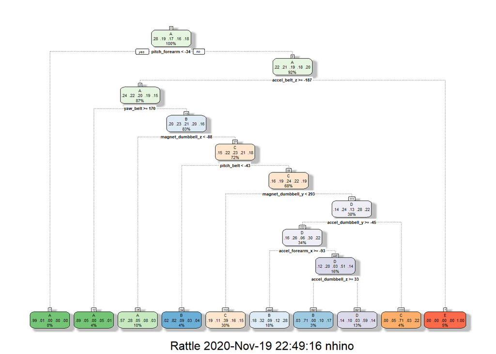

```r
DT <- train(classe ~., data = trainData3, method = "rpart")
fancyRpartPlot(DT$finalModel)
```

```r
DT$finalModel
```

```
## n= 13737
##
## node), split, n, loss, yval, (yprob)
##       * denotes terminal node
##
##   1) root 13737 9831 A (0.28 0.19 0.17 0.16 0.18)
##     2) pitch_forearm< -33.95 1087    7 A (0.99 0.0064 0 0 0) *
##     3) pitch_forearm>=-33.95 12650 9824 A (0.22 0.21 0.19 0.18 0.2)
##       6) accel_belt_z>=-187.5 11923 9099 A (0.24 0.22 0.2 0.19 0.15)
##        12) yaw_belt>=169.5 573   64 A (0.89 0.052 0 0.052 0.007) *
##        13) yaw_belt< 169.5 11350 8730 B (0.2 0.23 0.21 0.2 0.16)
##          26) magnet_dumbbell_z< -88.5 1418  616 A (0.57 0.28 0.045 0.075 0.032) *
##          27) magnet_dumbbell_z>=-88.5 9932 7600 C (0.15 0.22 0.23 0.21 0.18)
##            54) pitch_belt< -42.95 589  104 B (0.022 0.82 0.093 0.025 0.036) *
##            55) pitch_belt>=-42.95 9343 7066 C (0.16 0.19 0.24 0.22 0.19)
##             110) magnet_dumbbell_y< 292.5 4111 2494 C (0.19 0.11 0.39 0.16 0.15) *
##             111) magnet_dumbbell_y>=292.5 5232 3793 D (0.14 0.24 0.13 0.28 0.22)
##               222) accel_dumbbell_y>=-45.5 4712 3288 D (0.16 0.26 0.062 0.3 0.22)
##                 444) accel_forearm_x>=-93.5 2531 1722 B (0.18 0.32 0.093 0.12 0.28) *
##                 445) accel_forearm_x< -93.5 2181 1069 D (0.12 0.2 0.026 0.51 0.14)
##                   890) accel_dumbbell_z>=32.5 355  103 B (0.025 0.71 0 0.099 0.17) *
##                   891) accel_dumbbell_z< 32.5 1826  749 D (0.14 0.1 0.031 0.59 0.14) *
##               223) accel_dumbbell_y< -45.5 520  152 C (0 0.048 0.71 0.029 0.22) *
##       7) accel_belt_z< -187.5 727    3 E (0.0028 0.0014 0 0 1) *
```

I then check the accuracy of the model, as follows:

```r
DTpredict <- predict(DT, valData3)
DTcheck <- confusionMatrix(DTpredict, valData3$classe)
DTcheck
```

```
## Confusion Matrix and Statistics
##
##           Reference
## Prediction    A    B    C    D    E
##          A 1043  181   34   50   15
##          B  214  690  127  158  333
##          C  323  200  842  279  313
##          D   90   68   23  477  117
##          E    4    0    0    0  304
##
## Overall Statistics
##
##                Accuracy : 0.5703
##                  95% CI : (0.5575, 0.583)
##     No Information Rate : 0.2845
##     P-Value [Acc > NIR] : < 2.2e-16
##
##                   Kappa : 0.4607
##
##  Mcnemar's Test P-Value : < 2.2e-16
##
## Statistics by Class:
##
##                      Class: A Class: B Class: C Class: D Class: E
## Sensitivity            0.6231   0.6058   0.8207  0.49481  0.28096
## Specificity            0.9335   0.8247   0.7705  0.93944  0.99917
## Pos Pred Value         0.7884   0.4534   0.4303  0.61548  0.98701
## Neg Pred Value         0.8617   0.8971   0.9532  0.90470  0.86050
## Prevalence             0.2845   0.1935   0.1743  0.16381  0.18386
## Detection Rate         0.1772   0.1172   0.1431  0.08105  0.05166
## Detection Prevalence   0.2248   0.2586   0.3325  0.13169  0.05234
## Balanced Accuracy      0.7783   0.7152   0.7956  0.71713  0.64006
```

## Prediction

I will now use the Random Forest model to predict “classe” based on the data contained in the “pml-testing.csv” data set, as follows:

```r
NHprediction <- predict(RF, testData)
NHprediction
```

```
##  [1] B A B A A E D B A A B C B A E E A B B B
## Levels: A B C D E
```